# Linear Regression Modelling Assignment

Mohd Azmi

31/10/2019

# Pre-amble

## Problem Background

A team of researchers wanted to find relationship between weight and head circumference among newborn. The researchers also wanted to know is there any other factors that can be used to predict the head circumference.

In this dataset, 550 terms babies were sampled from a population. their weight, length and head circumference were recorded at one month of age. The babies also had their gender and parity recorded. (Parity is their birth order in the family). Mother’s education level were also recorded.

*Dataset Source: [Medical Statistics: A Guide to Data Analysis and Critical Appraisal](https://www.wiley.com/en-us/Medical+Statistics%3A+A+Guide+to+Data+Analysis+and+Critical+Appraisal-p-9780470755204)*

## Loading Library

```r
library(foreign)
library(tidyverse)
library(corrplot)
library(knitr)
library(broom)
library(tidyr)
library(psych)
library(rmdformats)
library(car)
library(DT)
```

## Loading Dataset

```r
Data01 <- read.spss("weights.sav", use.value.label=T, to.data.frame=T)
datatable(Data01)
```

|  | id | weight | length | headc | gender | educatio | parity |
| --- | --- | --- | --- | --- | --- | --- | --- |
| 1 | L001 | 3.95 | 55.5 | 37.5 | Female | tertiary | 3 or more siblings |
| 2 | L003 | 4.63000020980835 | 57 | 38.5 | Female | tertiary | Singleton |
| 3 | L004 | 4.75 | 56 | 38.5 | Male | secondary | 2 siblings |
| 4 | L005 | 3.92000007629395 | 56 | 39 | Male | tertiary | One sibling |
| 5 | L006 | 4.55999994277954 | 55 | 39.5 | Male | primary | 2 siblings |
| 6 | L007 | 3.63999996185303 | 51.5 | 34.5 | Female | tertiary | Singleton |
| 7 | L008 | 3.55 | 56 | 38 | Female | primary | 3 or more siblings |
| 8 | L009 | 4.53000020980835 | 57 | 39.7000007629395 | Male | primary | 3 or more siblings |
| 9 | L010 | 4.96999979019165 | 58.5 | 39 | Male | tertiary | 2 siblings |
| 10 | L011 | 3.74000000953674 | 52 | 38 | Male | primary | One sibling |

[output cut: 540 more lines]

# Descriptive Analysis and Data Exploration

In the first step, data exploration was done to get the overview of the data.

## Descriptive Analysis

Descriptive analysis was done to the dataset to get the overview of the data, including statistic for each variables.

```r
kable(summary(Data01[, 5:6]))
```

|  | gender | educatio |
| --- | --- | --- |
|  | Male :275 | primary :198 |
|  | Female:275 | secondary: 99 |
|  | NA | tertiary :253 |

```r
kable(describe(Data01))
```

|  | vars | n | mean | sd | median | trimmed | mad | min | max | range | skew | kurtosis | se |
| --- | --- | --- | --- | --- | --- | --- | --- | --- | --- | --- | --- | --- | --- |
| id* | 1 | 550 | 275.500000 | 158.9155960 | 275.50 | 275.500000 | 203.8575000 | 1.00 | 550.00 | 549.000000 | 0.0000000 | -1.2065474 | 6.7761838 |
| weight | 2 | 550 | 4.366418 | 0.6018215 | 4.33 | 4.356341 | 0.6226921 | 2.92 | 6.49 | 3.570000 | 0.1998029 | -0.1657875 | 0.0256618 |
| length | 3 | 550 | 54.840909 | 2.4069078 | 55.00 | 54.789773 | 2.5945500 | 48.00 | 62.00 | 14.000000 | 0.2218894 | -0.1608705 | 0.1026309 |
| headc | 4 | 550 | 37.895273 | 1.3615643 | 38.00 | 37.905909 | 1.4826000 | 34.00 | 41.20 | 7.200001 | -0.1200177 | -0.2247489 | 0.0580573 |
| gender* | 5 | 550 | 1.500000 | 0.5004552 | 1.50 | 1.500000 | 0.7413000 | 1.00 | 2.00 | 1.000000 | 0.0000000 | -2.0036331 | 0.0213395 |
| educatio* | 6 | 550 | 2.100000 | 0.9008193 | 2.00 | 2.125000 | 1.4826000 | 1.00 | 3.00 | 2.000000 | -0.1969924 | -1.7412154 | 0.0384111 |
| parity* | 7 | 550 | 2.109091 | 0.9894291 | 2.00 | 2.011364 | 1.4826000 | 1.00 | 4.00 | 3.000000 | 0.4793912 | -0.8408664 | 0.0421894 |

Based on the descriptive analysis, we can conclude that

## Data Exploration

For data exploration, numerical data can be plotted into histogram, which can then be use to assess (qualitatively / eyeball) whether the data is normally distributed.

### Histogram

Histogram for *Weight*

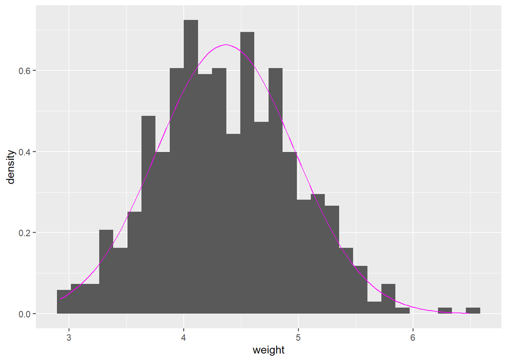

```r
ggplot(Data01, aes(weight)) +
  geom_histogram(aes(y=..density..)) +
  stat_function(fun = dnorm, colour = "magenta",
                args = list(mean = mean(Data01$weight),
                            sd = sd(Data01$weight)))
```

The weight distribution look normally distributed

Histogram for *Length*

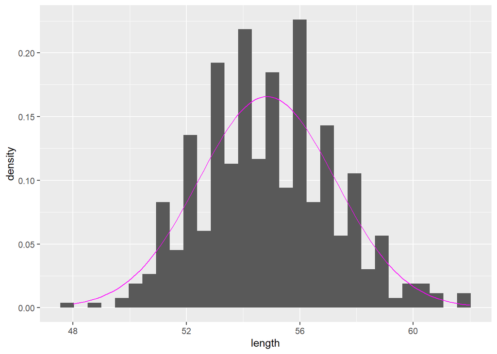

```r
ggplot(Data01, aes(length)) +
  geom_histogram(aes(y=..density..)) +
  stat_function(fun = dnorm, colour = "magenta",
                args = list(mean = mean(Data01$length),
                            sd = sd(Data01$length)))
```

The length distribution look normally distributed

Histogram for *Head Circumference*

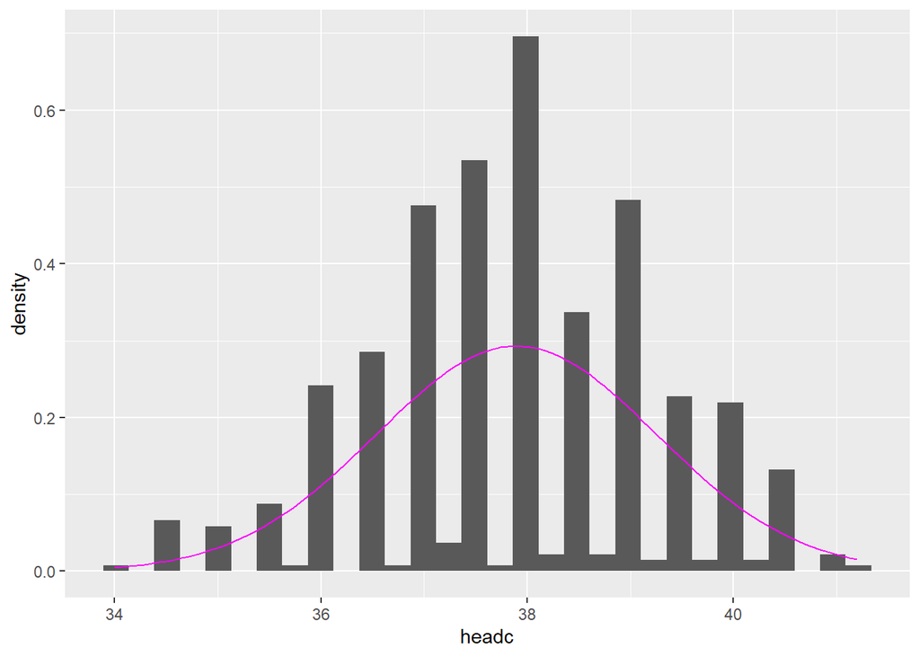

```r
ggplot(Data01, aes(headc)) +
  geom_histogram(aes(y=..density..)) +
  stat_function(fun = dnorm, colour = "magenta",
                args = list(mean = mean(Data01$headc),
                            sd = sd(Data01$headc)))
```

### Correlation

Correlation between numerical data can be calculated using correlation matrix and visualized using correlogram.

- Correlation Matrix and Correlogram

```r
Data02 <- Data01 %>% select_if(is.numeric)
CorData02 <- cor(Data02, use = "complete.obs", method = "pearson")
kable(round(CorData02,2))
```

|  | weight | length | headc |
| --- | --- | --- | --- |
| weight | 1.00 | 0.71 | 0.62 |
| length | 0.71 | 1.00 | 0.60 |
| headc | 0.62 | 0.60 | 1.00 |

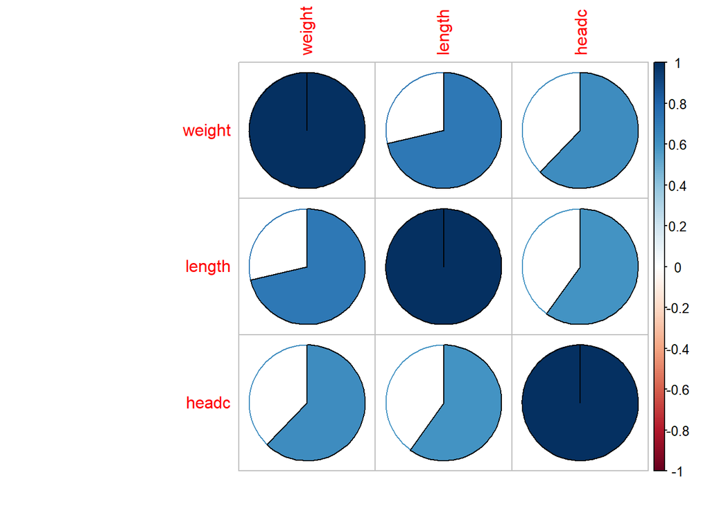

```r
corrplot(CorData02, method = "pie")
```

Based on the correlation Matrix, we can conclude that

- weight and length had high correlation, with r = 0.71
- other combination had moderate correlation, with 0.3 < r < 0.7

# Modelling - Univariable

Simple linear regression will be done to assess the association of each variable with head circumference.

## Univariable Models

### ModelWeight

ModelWeight was done using these variables

- outcome: Head Circumference
- covariate: weight

```r
ModelWeight <- lm(headc ~ weight, data = Data01)
summary(ModelWeight)
```

```
##
## Call:
## lm(formula = headc ~ weight, data = Data01)
##
## Residuals:
##     Min      1Q  Median      3Q     Max
## -4.1255 -0.6117  0.0257  0.6825  3.9024
##
## Coefficients:
##             Estimate Std. Error t value Pr(>|t|)
## (Intercept) 31.74618    0.33339   95.22   <2e-16 ***
## weight       1.40827    0.07564   18.62   <2e-16 ***
## ---
## Signif. codes:  0 '***' 0.001 '**' 0.01 '*' 0.05 '.' 0.1 ' ' 1
##
## Residual standard error: 1.067 on 548 degrees of freedom
## Multiple R-squared:  0.3875, Adjusted R-squared:  0.3863
## F-statistic: 346.6 on 1 and 548 DF,  p-value: < 2.2e-16
```

```r
kable(tidy(ModelWeight, conf.int = T))
```

| term | estimate | std.error | statistic | p.value | conf.low | conf.high |
| --- | --- | --- | --- | --- | --- | --- |
| (Intercept) | 31.746184 | 0.3333887 | 95.22274 | 0 | 31.09131 | 32.401060 |
| weight | 1.408268 | 0.0756391 | 18.61826 | 0 | 1.25969 | 1.556847 |

The weight is significantly associated with head circumference, in which for each increase in 1 kg of weight, the head circumference increase by 1.41 cm.

### ModelLength

ModelLength was done using these variables

- outcome: Head Circumference
- covariate: length

```r
ModelLength <- lm(headc ~ length, data = Data01)
summary(ModelLength)
```

```
##
## Call:
## lm(formula = headc ~ length, data = Data01)
##
## Residuals:
##     Min      1Q  Median      3Q     Max
## -4.3029 -0.7627  0.0509  0.7201  2.9124
##
## Coefficients:
##             Estimate Std. Error t value Pr(>|t|)
## (Intercept) 19.33512    1.06292   18.19   <2e-16 ***
## length       0.33844    0.01936   17.48   <2e-16 ***
## ---
## Signif. codes:  0 '***' 0.001 '**' 0.01 '*' 0.05 '.' 0.1 ' ' 1
##
## Residual standard error: 1.092 on 548 degrees of freedom
## Multiple R-squared:  0.3579, Adjusted R-squared:  0.3568
## F-statistic: 305.5 on 1 and 548 DF,  p-value: < 2.2e-16
```

```r
kable(tidy(ModelLength, conf.int = T))
```

| term | estimate | std.error | statistic | p.value | conf.low | conf.high |
| --- | --- | --- | --- | --- | --- | --- |
| (Intercept) | 19.3351183 | 1.0629231 | 18.19051 | 0 | 17.2472159 | 21.4230206 |
| length | 0.3384363 | 0.0193633 | 17.47821 | 0 | 0.3004009 | 0.3764717 |

The length is significantly associated with head circumference, in which for each increase in 1cm of length, the head circumference increase by 0.34 cm.